[figure not shown]

# ShopCart Superstore Sales & Profit Analysis

## Introduction

ShopCart is an e-commerce company that operates in North America. It sells products across different categories such as Furniture, Office Supplies, and Technology. Over the years, the company has experienced steady growth in sales and customer demand.

Despite this growth, the company began facing challenges related to profitability, operational efficiency, and sales performance across different product categories and regions.

### Business Objective

The primary objective of this project is to analyze ShopCart’s historical sales data from 2022–2025 to evaluate sales performance and identify the key drivers of profitability across products, regions, categories, and customer segments in the United States.

### Core Questions to Answer

1. **Business Summary:** What are the company’s total sales, profit, and other key performance indicators (KPIs)?
2. **Trend Over Time:** How have sales and profits changed over time? Are there any noticeable seasonal patterns or trends?
3. **Profitability Drivers:** Which products categories and sub-categories are the most & least profitable?
4. **Regional Performance:** Which geographical regions and states contribute most to sales and profit? Are there any regions with high sales but low profitability ?
5. **Customer Segment Analysis:** Which customer segment is most valuable ?
6. **Discount Impact:** How do discounts affect profitability? What are the tipping points where discounts begin to negatively impact profit?

### About Data

The dataset for this project is stored in the **shopcart_analytics** database across four main tables: **orders**, **customers**, **products**, and **shipping_address**.

- The **orders** table contains transactional details such as Order ID, Order Date, Ship Date, Ship Mode,Quantity, Sales, Discount, and Profit.
- The **customers** table includes information about each customer, including Customer ID, First name, Last Nnmae, and the customer segment.
- The **products** table contains details about each product, such as Product ID, Product Name, Category, and Sub-Category.
- The **shipping_address** table contains location details, such as Postal Code, City, State, Country, and Region.

These tables are joined to create a single dataset for analyzing sales and profit trends in the United States between January 2022 and December 2025.

## 1) Importing Libraries

```python
from sqlalchemy import create_engine
import pandas as pd
import numpy as np
import matplotlib.pyplot as plt
import seaborn as sns
from matplotlib.patches import Patch
import os
```

```python
pd.set_option("display.max_columns",None)
```

```python
# Colours
orange = "#F59E0B"
blue =  '#2196F3'
green= '#006400'
title_text = "#222021"
grid_color = '#BEBDB8'

colors = ["#344771","#b3cde0","#03396c", "#6497b1", "#011f4b","#7b8dd2",]
```

## 2) Loading Data from Database & Basic Inspection

```python
# Logging into Database using credentials

host = "localhost"
password = os.getenv("MYSQL_PASS")
username = "root"
database = "ShopCart_Analytics"
port = "3306"

engine = create_engine(f"mysql+pymysql://{username}:{password}@{host}:{port}/{database}")
```

```python
query = """
    SELECT
        o.`Row ID`,
        o.`Order ID`,
        o.`Order Date`,
        o.`Ship Date`,
        o.`Ship Mode`,
        c.`Customer ID`,
        CONCAT(c.`First Name`, ' ', c.`Last Name`) AS `Customer Name`,
        c.`Segment`,
        a.`Postal Code`,
        a.`City`,
        a.`State`,
        a.`Country`,
        a.`Region`,
        p.`Product ID`,
        p.`Product Name`,
        p.`Category`,
        p.`Sub-Category`,
        o.`Sales`,
        o.`Quantity`,
        o.`Discount`,
        o.`Profit`
    FROM shopcart_analytics.orders o
    INNER JOIN shopcart_analytics.customers  c
        ON o.`Customer ID` = c.`Customer ID`
    INNER JOIN shopcart_analytics.products p
        ON o.`Product ID` = p.`Product ID`
    INNER JOIN shopcart_analytics.shipping_address a
        ON o.`Address ID` = a.`Address ID`

        WHERE
            a.`Country` = 'United States'
            AND o.`Order Date` BETWEEN '2022-01-01' AND '2025-12-31'
        ORDER BY
            o.`Order Date`;
"""

# Loading Data
df = pd.read_sql(query, engine)
```

```python
df.head(3)
```

|  | Row ID | Order ID | Order Date | Ship Date | Ship Mode | Customer ID | Customer Name | Segment | Postal Code | City | State | Country | Region | Product ID | Product Name | Category | Sub-Category | Sales | Quantity | Discount | Profit |
| --- | --- | --- | --- | --- | --- | --- | --- | --- | --- | --- | --- | --- | --- | --- | --- | --- | --- | --- | --- | --- | --- |
| 0 | 7981 | CA-2022-103800 | 2022-01-03 | 2022-01-07 | Standard Class | DP-13000 | Darren Powers | Consumer | 77095 | Houston | Texas | United States | Central | OFF-PA-10000174 | Message Book, Wirebound, Four 5 1/2" X 4" Form... | Office Supplies | Paper | 16.448 | 2 | 0.2 | 5.5512 |
| 1 | 740 | CA-2022-112326 | 2022-01-04 | 2022-01-08 | Standard Class | PO-19195 | Phillina Ober | Home Office | 60540 | Naperville | Illinois | United States | Central | OFF-LA-10003223 | Avery 508 | Office Supplies | Labels | 11.784 | 3 | 0.2 | 4.2717 |
| 2 | 741 | CA-2022-112326 | 2022-01-04 | 2022-01-08 | Standard Class | PO-19195 | Phillina Ober | Home Office | 60540 | Naperville | Illinois | United States | Central | OFF-ST-10002743 | SAFCO Boltless Steel Shelving | Office Supplies | Storage | 272.736 | 3 | 0.2 | -64.7748 |

```python
# Data Shape
print(f"Number of rows: {df.shape[0]}.")
print(f"Number of columns: {df.shape[1]}.")
```

```
Number of rows: 9994.
Number of columns: 21.
```

```python
# Basic Data Summary
df_info = pd.DataFrame({
    "dtype": df.dtypes,
    "null_count": df.isna().sum(),
    "null_prct": df.isna().mean() * 100,
    "unique_count": df.nunique()})

df_info
```

|  | dtype | null_count | null_prct | unique_count |
| --- | --- | --- | --- | --- |
| Row ID | int64 | 0 | 0.0 | 9994 |
| Order ID | object | 0 | 0.0 | 5009 |
| Order Date | object | 0 | 0.0 | 1237 |
| Ship Date | object | 0 | 0.0 | 1334 |
| Ship Mode | object | 0 | 0.0 | 4 |
| Customer ID | object | 0 | 0.0 | 793 |
| Customer Name | object | 0 | 0.0 | 793 |
| Segment | object | 0 | 0.0 | 3 |
| Postal Code | int64 | 0 | 0.0 | 631 |
| City | object | 0 | 0.0 | 530 |
| State | object | 0 | 0.0 | 49 |
| Country | object | 0 | 0.0 | 1 |
| Region | object | 0 | 0.0 | 4 |
| Product ID | object | 0 | 0.0 | 1862 |
| Product Name | object | 0 | 0.0 | 1818 |
| Category | object | 0 | 0.0 | 3 |
| Sub-Category | object | 0 | 0.0 | 17 |
| Sales | float64 | 0 | 0.0 | 5825 |
| Quantity | int64 | 0 | 0.0 | 14 |
| Discount | float64 | 0 | 0.0 | 12 |
| Profit | float64 | 0 | 0.0 | 7287 |

```python
# Numeric Columns Summary
df.describe()
```

|  | Row ID | Postal Code | Sales | Quantity | Discount | Profit |
| --- | --- | --- | --- | --- | --- | --- |
| count | 9994.000000 | 9994.000000 | 9994.000000 | 9994.000000 | 9994.000000 | 9994.000000 |
| mean | 4997.500000 | 55190.379428 | 229.858001 | 3.789574 | 0.156203 | 28.656896 |
| std | 2885.163629 | 32063.693350 | 623.245101 | 2.225110 | 0.206452 | 234.260108 |
| min | 1.000000 | 1040.000000 | 0.444000 | 1.000000 | 0.000000 | -6599.978000 |
| 25% | 2499.250000 | 23223.000000 | 17.280000 | 2.000000 | 0.000000 | 1.728750 |
| 50% | 4997.500000 | 56430.500000 | 54.490000 | 3.000000 | 0.200000 | 8.666500 |
| 75% | 7495.750000 | 90008.000000 | 209.940000 | 5.000000 | 0.200000 | 29.364000 |
| max | 9994.000000 | 99301.000000 | 22638.480000 | 14.000000 | 0.800000 | 8399.976000 |

```python
# Checking for Duplicates
df.duplicated().sum()
```

```
np.int64(0)
```

**Insights**

- No missing values detected in the dataset.
- No duplicate values detected in the dataset.

## 3) Data Cleaning and Pre-processing

```python
# 1) Standardizing column names (in snake case)
df.columns = df.columns.str.strip().str.replace(" ", "_").str.replace("-", "_").str.lower()
df.columns
```

```
Index(['row_id', 'order_id', 'order_date', 'ship_date', 'ship_mode',
       'customer_id', 'customer_name', 'segment', 'postal_code', 'city',
       'state', 'country', 'region', 'product_id', 'product_name', 'category',
       'sub_category', 'sales', 'quantity', 'discount', 'profit'],
      dtype='object')
```

```python
# 2) Parsing date columns
df["order_date"] = pd.to_datetime(df["order_date"])
df["ship_date"] = pd.to_datetime(df["ship_date"])
```

```python
# 3) Droping country column (it contain only "USA.")
df.drop(columns="country", inplace=True)
```

## 4) Feature Enginnering

#### 4.1) Creating new columns:

```python
# a) 'days_to_ship' - Shipping time in days
df["days_to_ship"] = (df["ship_date"] - df["order_date"]).dt.days
```

```python
# b) 'profit_margin_pct' - Profit margin percentage
df["profit_margin_pct"] = df["profit"] / df["sales"] * 100
```

```python
# c) 'revenue_per_unit' - revenue generated per unit sold
df["revenue_per_unit"] = (df["sales"] / df["quantity"]).round(2)
```

```python
# d) 'discount_bucket' - categorizing discount into discount groups
bins   = [-0.1, 0.001, 0.10, 0.20, 0.30, 0.40, 0.50, 1.0]
labels = ['No Discount', '1-10%', '11-20%', '21-30%', '31-40%', '41-50%', '>51%']
df['discount_bucket'] = pd.cut(df['discount'], bins=bins, labels=labels)
```

## 5) Executive KPI Summary

```python
# ShopCart - Executive Summary

total_sales = round(df["sales"].sum())
total_profit = round(df["profit"].sum())
overall_margin = round(total_profit/ total_sales * 100,2)
total_orders = df["order_id"].nunique()
total_customers = df["customer_id"].nunique()
avg_ship_days = df["days_to_ship"].mean().round(2)
loss_making_orders = (df["profit"] < 0).sum()
loss_making_prct = ((df["profit"] < 0).mean() * 100).round(2)
avg_discount = df["discount"].mean().round(2) * 100


print("-" * 50)
print("      ShopCart - Executive Summary (2022-2025)")
print("-" * 50)
print(f"    Total Revenue:          ${total_sales}")
print(f"    Total Profit:           ${total_profit}")
print(f"    Overall Profit Margin:  {overall_margin} %")
print(f"    Average Discount:       {avg_discount} %")
print(f"    Loss-making orders:     {loss_making_orders} ({loss_making_prct} %)")
print(f"    Total Orders:           {total_orders}")
print(f"    Total Customers:        {total_customers}")
print(f"    Average Shipping Days:  {avg_ship_days}")
```

```
--------------------------------------------------
      ShopCart - Executive Summary (2022-2025)
--------------------------------------------------
    Total Revenue:          $2297201
    Total Profit:           $286397
    Overall Profit Margin:  12.47 %
    Average Discount:       16.0 %
    Loss-making orders:     1871 (18.72 %)
    Total Orders:           5009
    Total Customers:        793
    Average Shipping Days:  3.96
```

## 6) Sales and Profit Trend over Time

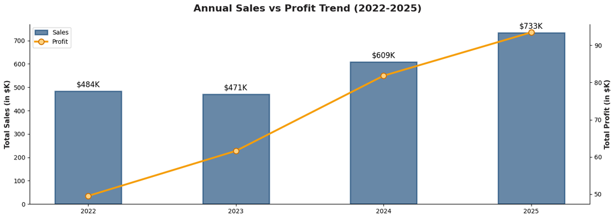

```
Year Over Year Summary Table:
 Year  Sales  Profit  Orders  Profit Margin (%)  Sales YoY Change (%)
 2022 484247   49544     969              10.23                   NaN
 2023 470533   61619    1038              13.10                 -2.83
 2024 609206   81795    1315              13.43                 29.47
 2025 733215   93439    1687              12.74                 20.36
```

```python
# 1) Yearly Sales and Profit Trend
yearly_summary = df.groupby(df["order_date"].dt.year).agg(
    Sales = ("sales", lambda x: round(x.sum())),
    Profit = ("profit", lambda x: round(x.sum())),
    Orders = ("order_id", "nunique")).reset_index()

yearly_summary["Profit Margin (%)"] = round(yearly_summary["Profit"]/ yearly_summary["Sales"] * 100,2)
yearly_summary["Sales YoY Change (%)"] = round(yearly_summary["Sales"].pct_change() * 100,2)
yearly_summary.rename(columns={"order_date": "Year"}, inplace=True)

# Bar Graph
fig, axes = plt.subplots(figsize=(14,5))
fig.suptitle("Annual Sales vs Profit Trend (2022-2025)", fontsize=16, fontweight="bold", color=title_text)

bars = axes.bar(yearly_summary["Year"].astype(str), yearly_summary["Sales"]/1e3,label='Sales',
                color="#03396C", alpha=0.6, width=0.45, linewidth=2 ,edgecolor="#03396C")
axes.set_ylabel("Total Sales (in $K)", fontsize=11, fontweight="bold", color = title_text)

for bar in bars:
    h = bar.get_height() + 10
    x_pos = bar.get_x() + bar.get_width()/2
    axes.text(x_pos,h,f"${bar.get_height():.0f}K",ha='center', va='bottom', fontsize=12)


ax2 = axes.twinx()
ax2.plot(yearly_summary["Year"].astype(str), yearly_summary["Profit"]/1e3, label = "Profit",
                color= orange, marker='o', linewidth=3, markersize=9, markerfacecolor="#FFD27F",
                markeredgecolor="#CC7000",  markeredgewidth=1.5)
ax2.set_ylabel("Total Profit (in $K)", fontsize=11, fontweight="bold", color = title_text)

handles1, labels1 = axes.get_legend_handles_labels()
handles2, labels2 = ax2.get_legend_handles_labels()

axes.legend(handles1 + handles2, labels1 + labels2, loc='upper left', fontsize=10)
axes.spines["top"].set_visible(False)
ax2.spines["top"].set_visible(False)

plt.tight_layout()
plt.show()

print("\nYear Over Year Summary Table: ")
print(yearly_summary.to_string(index=False))
```

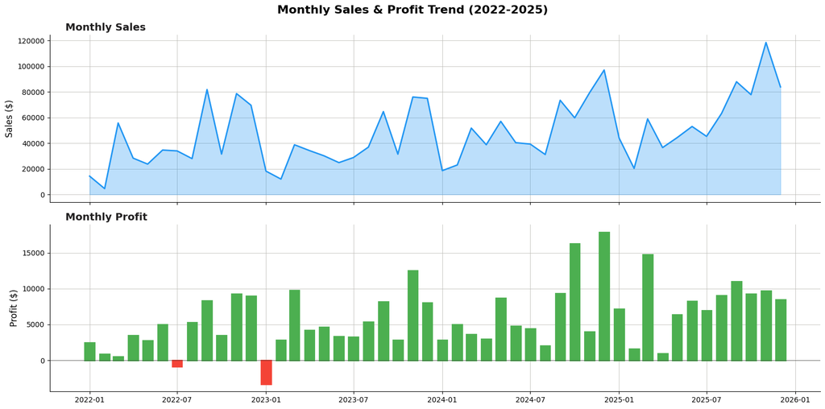

```python
# 2) Monthly Sales and Profit Trend
monthly = df.groupby(df["order_date"].dt.to_period("M")).agg(
    sales = ("sales", "sum"),
    profit = ("profit", "sum")).reset_index()
monthly["order_date"] = monthly["order_date"].dt.to_timestamp()

colors_rg = ['#4CAF50' if x>=0 else '#F44336' for x in monthly['profit']]


fig, axes = plt.subplots(2, 1, figsize = (16, 8), sharex=True)
fig.suptitle("Monthly Sales & Profit Trend (2022-2025)", fontsize= 16, fontweight="bold", color="black")

axes[0].plot(monthly["order_date"], monthly["sales"], linewidth=2, color= blue)
axes[0].fill_between(monthly["order_date"], monthly["sales"], alpha = 0.3, color = blue)
axes[0].set_title("Monthly Sales", fontsize=14, fontweight="bold", color=title_text, loc="left", x=0.02)
axes[0].set_ylabel("Sales ($)", fontsize=12)

axes[1].bar(monthly["order_date"], monthly["profit"], width=20,  color=colors_rg, linewidth=2, edgecolor=colors_rg)
axes[1].axhline(0, color = title_text, linewidth=0.4)
axes[1].set_title("Monthly Profit", fontsize=14, fontweight="bold", color=title_text, loc="left", x=0.02)
axes[1].set_ylabel("Profit ($)", fontsize=12)

for ax in axes:
    ax.spines["top"].set_visible(False)
    ax.spines["right"].set_visible(False)
    ax.grid(linewidth=0.6,color=grid_color)
    ax.set_axisbelow(True)

plt.tight_layout()
plt.show()
```

### Insights: Sales and Profit Trend over Time

- Both sales and profit shows an overall positive growth trend from 2022 to 2025, indicating consistent business expansion over time.
- This trend also shows strong seasonal patterns, with sales and profits consistently peaking between September and December for each year. This suggests increased customer demand and higher purchasing activity during the year-end and festival seasons.
- A few month periods shows losses, particularly in July 2022 and January 2023. These negative profit periods may indicate operational inefficiencies, higher costs, or the impact of aggressive discounting strategies.

## 7) Category and Sub-Category Analysis

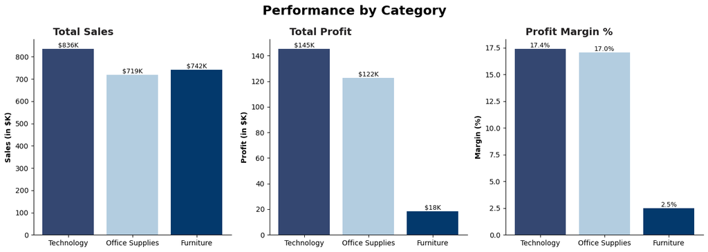

```
 Sales and Profit by Category:
       category  Sales  Profit  Orders  Avg_Discount  Margin %  Sales %  Profit %
     Technology 836154  145455    1847      0.132323     17.40     36.4     50.79
Office Supplies 719047  122491    6026      0.157285     17.04     31.3     42.77
      Furniture 742000   18451    2121      0.173923      2.49     32.3      6.44
```

```python
# 1) Sales and Profit Performace by Category
cat_summary = df.groupby("category").agg(
    Sales = ("sales", lambda x: round(x.sum())),
    Profit= ("profit", lambda x: round(x.sum())),
    Orders = ("order_id", "count"),
    Avg_Discount = ("discount", "mean")).reset_index()

cat_summary["Margin %"] = round(cat_summary["Profit"]/ cat_summary["Sales"] * 100, 2)
cat_summary["Sales %"] = (cat_summary["Sales"]/ cat_summary["Sales"].sum() * 100).round(2)
cat_summary["Profit %"] = (cat_summary["Profit"]/ cat_summary["Profit"].sum() * 100).round(2)
cat_summary.sort_values("Profit", ascending=False, inplace=True)


# Chart
fig, axes = plt.subplots(1, 3, figsize=(14, 5))
fig.suptitle('Performance by Category', fontsize=18,fontweight='bold', color = "black")

charts = [ ("Sales", "Total Sales", "Sales (in $K)", '${:,.0f}K', 1e3),
           ("Profit", "Total Profit", "Profit (in $K)", '${:,.0f}K', 1e3),
           ("Margin %", "Profit Margin %", "Margin (%)", '{:.1f}%', 1)]

for ax, (col, chart_title, ylabel, fmt, scale) in zip(axes, charts):
    bars = ax.bar(cat_summary["category"], cat_summary[col] / scale, color=colors)
    ax.set_title(chart_title, fontsize=14, fontweight='bold',color=title_text, loc="left", x=0.1)
    ax.set_ylabel(ylabel, fontsize=10, fontweight='bold')

    for bar in bars:
        h = bar.get_height()
        x_pos = bar.get_x() + bar.get_width()/2
        ax.text(x_pos,h,fmt.format(h),
            ha='center', va='bottom', fontsize=9)

    ax.spines["top"].set_visible(False)
    ax.spines["right"].set_visible(False)
    ax.spines["left"].set_color("black")
    ax.spines["bottom"].set_color("black")
    ax.grid(False)

plt.tight_layout()
plt.show()

print("\n Sales and Profit by Category: ")
print(cat_summary.to_string(index=False))
```

### Insights : Category wise Analysis

```
- Technology and Office Supplies together contribute more than **93% of total profit**, while Furniture contributes minimal despite high sales.
```

[figure not shown]

[output not shown]

```python
# 2) Sub-category
sub_cat = (df.groupby(["category", "sub_category"]).agg(
    Sales=('sales', lambda x: round(x.sum())),
    Profit =('profit', lambda x: round(x.sum())),
    Avg_Discount_prct = ("discount", lambda x: round(x.mean() * 100,2))))
sub_cat["Margin_prct"] = sub_cat["Profit"] / sub_cat["Sales"] * 100
sub_cat = sub_cat.reset_index().sort_values("Sales")

category_colors = { "Furniture": colors[0],"Office Supplies": colors[1], "Technology": colors[2]}

bar_colors = sub_cat["category"].map(category_colors)

# Chart
fig, axes = plt.subplots(1, 2, figsize=(14, 6))
fig.suptitle('Sub-Category: Sales vs Profit', fontsize=18,fontweight='bold', color= "black")

charts = [ ("Sales", "Total Sales by Sub-Category", "Sales (in $K)", '${:,.1f}K', 1e3, (0, 360) ),
           ("Profit", "Total Profit by Sub-Category","Profit (in $K)", '{:.1f}%', 1e3, (-25, 60))]

for ax, (col, title_txt, xlabel, fmt, scale, xlim) in zip(axes, charts):
    bars = ax.barh(sub_cat["sub_category"], sub_cat[col] / scale,color=bar_colors, linewidth=1)
    for bar in bars:
        w = bar.get_width()
        y = bar.get_y() + bar.get_height() / 2
        ax.text(w ,y , fmt.format(w),
            va='center', ha='left' if w >= 0 else 'right')

    ax.set_title(title_txt,fontsize=12, fontweight='bold', loc="left", color=title_text, x=0.05)
    ax.set_xlabel(xlabel, fontweight='bold')
    ax.set_xlim(xlim)
    ax.axvline(0, color='black', linewidth=0.8)

    ax.spines["top"].set_visible(False)
    ax.spines["right"].set_visible(False)
    ax.spines["left"].set_color("black")
    ax.spines["bottom"].set_color("black")
    ax.grid(False)

legends = [Patch(facecolor=color, label=category) for category, color in category_colors.items()]
axes[1].legend(handles=legends, loc='lower right', fontsize=10)

plt.tight_layout()
plt.show()

print("Three loss making sub-categories: ")
print(sub_cat.head(3).to_string(index=False))
```

### Insights: Sub-category wise analysis

- The sub-category analysis reveals that profitability varies significantly even within categories.
- **High performance sub-categories**
  - Copiers (Technology) and Phones (Technology) are the most profitable sub-categories, generating 55.6K USD and $44.5K USD profit respectively.
  - Accessories (Technology) also performs strongly with a 25% margin, showing Technology is the most consistently profitable category.
- **High Profit margin sub-categories**
  - Envelopes, Labels, Paper, and Fasteners show high profit margins (31%–44%) despite having very low sales volumes. All of these sub-categories belong to Office Supplies.
- **Loss Making Sub-Categories**
  - Tables and Bookcases are both making losses, with profit margins of **-8.6% and -3.0%**.These both belong to the Furniture category.
  - These sub-categories also have high average discounts (**26% and 21%**), which may be contributing to the losses.
- Profit is heavily concentrated in a few high-performing sub-categories, mainly within Technology and select Office Supplies products.
- At the same time, a small number of Furniture sub-categories are significantly dragging overall profitability due to high discounts and negative margins.

## 8) Regional Performance Analysis

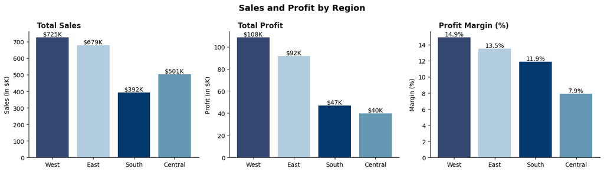

```
Summary Statistics by Geographic Region:
 Region  Sales  Profit  Orders  Customers  Discount_prct  Margin (%)
   West 725458  108418    3203        686          10.93        14.9
   East 678781   91523    2848        674          14.54        13.5
  South 391722   46749    1620        512          14.73        11.9
Central 501240   39706    2323        629          24.04         7.9
```

```python
# 1) Regional Summary Table

region_summary = df.groupby("region").agg(
    Sales = ("sales", lambda x: round(x.sum())),
    Profit = ("profit", lambda x: round(x.sum())),
    Orders = ("order_id", "count"),
    Customers = ("customer_id", "nunique"),
    Discount_prct = ("discount", lambda x: round(x.mean() * 100, 2))).reset_index()

region_summary["Margin (%)"] = (region_summary["Profit"] / region_summary["Sales"] * 100).round(1)
region_summary = region_summary.sort_values("Profit", ascending=False)
region_summary = region_summary.rename(columns={"region":"Region"})

# Chart
fig, axes = plt.subplots(1,3, figsize=(14,4))
fig.suptitle('Sales and Profit by Region', fontsize=14, fontweight='bold')

charts = [ ("Sales", "Total Sales", "Sales (in $K)", 1e3, '${:,.0f}K'),
           ("Profit", "Total Profit", "Profit (in $K)", 1e3, '${:,.0f}K'),
           ("Margin (%)", "Profit Margin (%)", "Margin (%)", 1, '{:,.1f}%')]

for ax, (col, title_txt, ylabel, scale, fmt) in zip(axes, charts):
    bars = ax.bar(region_summary["Region"], region_summary[col]/ scale, color=colors)
    ax.set_title(title_txt, fontsize=12, fontweight='bold', loc="left", color=title_text, x=0.05)
    ax.set_ylabel(ylabel)

    for bar in bars:
        height = bar.get_height()
        x_pos= bar.get_x() + bar.get_width()/2
        ax.text(x_pos,height,fmt.format(height),
        ha='center',va='bottom')

    ax.spines["top"].set_visible(False)
    ax.spines["right"].set_visible(False)
    ax.spines["left"].set_color("black")
    ax.spines["bottom"].set_color("black")

plt.tight_layout()
plt.show()

print("\nSummary Statistics by Geographic Region: ")
print(region_summary.to_string(index=False))
```

### Insights: Geographic Region Analysis

- **West is the strongest performing region**
  - It generates the highest sales (**725K USD**), highest profit (**108K USD**), and the highest profit margin (**14.9%**).
- **East and South shows moderate performance**
  - **East** is the second-best performing region after West.
  - **South** shows moderate performance in terms of both sales and profitability.
- **Central is the weakest region**
  - Despite generating **501K USD in sales**, it produces only **39.7K USD profit**, the lowest among all regions.
  - It has the **lowest margin (7.9%)**, indicating poor profitability conversion.
  - It also has the **highest average discount (24%)**, which is likely reducing profitability.

## 9) Customer Segment Analysis

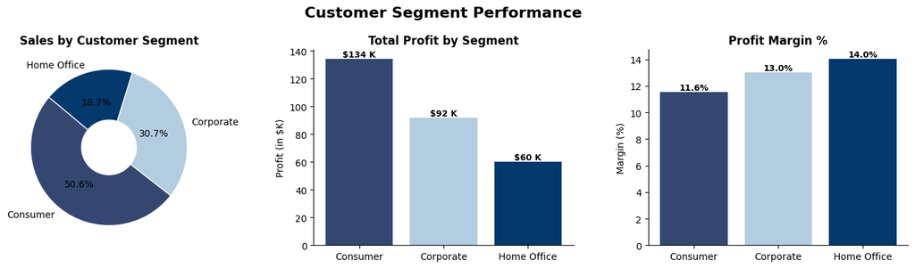

```
Customer Segment Performance:
       segment    Sales       Profit  Orders  Customers  Discount_prct  Margin (%)  Avg Order Value
0     Consumer  1161401  134119.2092    5191        409          15.81       11.55           223.73
1    Corporate   706146   91979.1340    3020        236          15.82       13.03           233.82
2  Home Office   429653   60298.6785    1783        148          14.71       14.03           240.97
```

```python
# Customer Segement Analysis

cust_seg = df.groupby("segment").agg(
    Sales = ("sales", lambda x: round(x.sum())),
    Profit = ("profit", "sum"),
    Orders = ("order_id", "count"),
    Customers = ("customer_id", "nunique"),
    Discount_prct = ("discount", lambda x: round(x.mean() * 100, 2))).reset_index()
cust_seg["Margin (%)"] = (cust_seg["Profit"]/ cust_seg["Sales"] * 100).round(2)
cust_seg["Avg Order Value"] = (cust_seg["Sales"]/ cust_seg["Orders"]).round(2)


# Chart
fig, axes = plt.subplots(1, 3, figsize=(14, 4))
fig.suptitle("Customer Segment Performance", fontsize=16, fontweight="bold")

axes[0].pie(cust_seg["Sales"],labels = cust_seg["segment"], autopct="%1.1f%%", startangle=140,
            wedgeprops=dict(width=0.65, edgecolor='white'), colors=colors)
axes[0].set_title("Sales by Customer Segment",fontsize=12, fontweight="bold")

bars = axes[1].bar(cust_seg["segment"], cust_seg["Profit"]/ 1e3, color=colors)
for bar in bars:
    height = bar.get_height()
    x_pos= bar.get_x() + bar.get_width()/2
    axes[1].text(x_pos,height,
        f'${height:.0f} K',ha='center',va='bottom',
        fontsize=9,fontweight='bold')

axes[1].set_title("Total Profit by Segment", fontsize=12, fontweight="bold")
axes[1].set_ylabel("Profit (in $K)")
axes[1].spines["top"].set_visible(False)
axes[1].spines["right"].set_visible(False)

bars = axes[2].bar(cust_seg["segment"], cust_seg["Margin (%)"], color=colors)
for bar in bars:
    height = bar.get_height()
    x_pos= bar.get_x() + bar.get_width()/2
    axes[2].text(x_pos,height,
        f'{height:.1f}%',ha='center',va='bottom',
        fontsize=9,fontweight='bold')

axes[2].set_title("Profit Margin %", fontsize=12, fontweight="bold")
axes[2].set_ylabel("Margin (%)")
axes[2].spines["top"].set_visible(False)
axes[2].spines["right"].set_visible(False)

plt.tight_layout()
plt.show()

print("\nCustomer Segment Performance: ")
print(cust_seg.to_string())
```

### Insight: Customer Segment Analysis

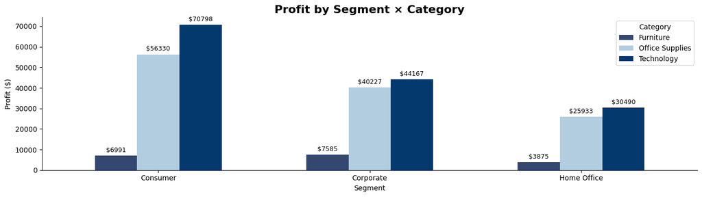

```python
# Profit by Segment × Category (Cross- Analysis)
seg_cat = (df.groupby(['segment','category'])['profit'].sum().unstack().fillna(0))

fig, ax = plt.subplots(figsize=(14, 4))
seg_cat.plot(kind='bar', ax=ax,color=colors, width=0.6)
ax.set_title('Profit by Segment × Category', fontsize=16, fontweight='bold')
ax.set_ylabel('Profit ($)'); ax.set_xlabel('Segment')
ax.legend(title='Category'); plt.xticks(rotation=0)

for container in ax.containers:
    ax.bar_label(container,fmt='$%.0f',padding=3,fontsize=9)

ax.spines["top"].set_visible(False)
ax.spines["right"].set_visible(False)

plt.tight_layout()
plt.show()
```

### Insights: Profit by Segment × Category

- **Technology is the most profitable category across all the customer segments**, generating the highest profit for each segments.
- **Consumer + Technology** is the strongest combination, contributing the highest overall profit (**70.8K**).
- **Office Supplies** also performs consistently well across all segments, making it a stable secondary profit driver.
- **Furniture is the weakest category across all the segments**, generating very low profit compared to Technology and Office Supplies.
- Even in the high-volume Consumer segment, Furniture contributes only **7K profit**, highlighting poor profitability efficiency.

## 10) Discount Impact Analysis

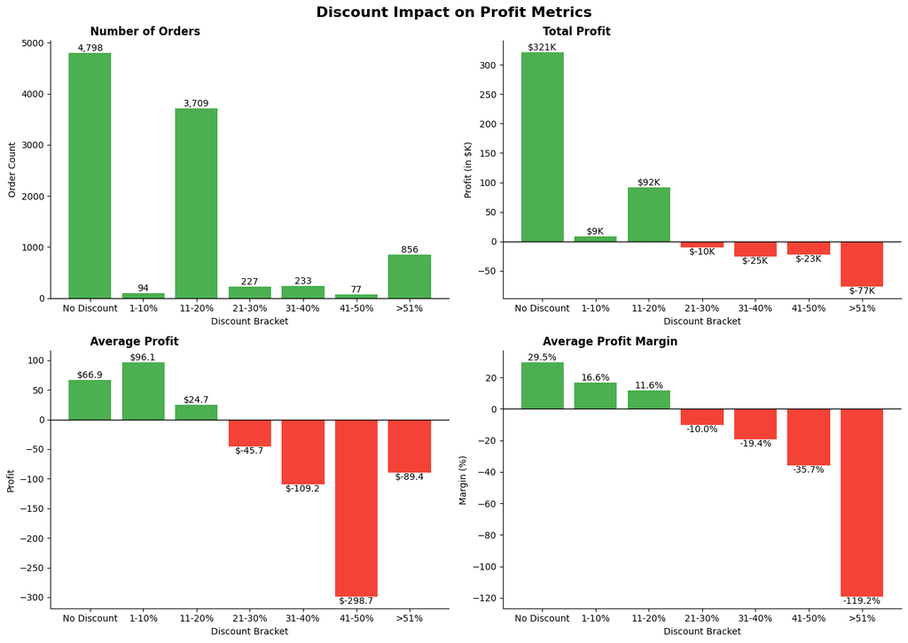

```
Discount Impact Analysis:
discount_bucket  Orders   Sales  Profit  Avg_Profit  Margin (%)
    No Discount    4798 1087908  320988       66.90       29.51
          1-10%      94   54369    9029       96.06       16.61
         11-20%    3709  792153   91756       24.74       11.58
         21-30%     227  103227  -10369      -45.68      -10.04
         31-40%     233  130911  -25448     -109.22      -19.44
         41-50%      77   64404  -23000     -298.70      -35.71
           >51%     856   64229  -76559      -89.44     -119.20
```

```python
# Discount impact Analysis
disc_bucket = df.groupby("discount_bucket", observed=True).agg(
    Orders = ("order_id", "count"),
    Sales = ("sales", lambda x: round(x.sum())),
    Profit = ("profit", lambda x: round(x.sum())),
    Avg_Profit = ("profit",lambda x: round(x.mean(),2))).reset_index()
disc_bucket["Margin (%)"] = (disc_bucket["Profit"] / disc_bucket["Sales"] * 100).round(2)

# Fig
fig, axes = plt.subplots(2,2, figsize = (14,10))
fig.suptitle("Discount Impact on Profit Metrics", fontsize=16, fontweight="bold")

for ax, (col, title_, y_label,scale, fmt) in zip(axes.flatten(), [
    ("Orders", "Number of Orders", "Order Count",1, '{:,.0f}'),
    ("Profit", "Total Profit", "Profit (in $K)",1e3, '${:,.0f}K'),
    ("Avg_Profit", "Average Profit", "Profit",1, '${:,.1f}'),
    ("Margin (%)", "Average Profit Margin", "Margin (%)",1, '{:,.1f}%')]):

    colors_rg = ['#4CAF50' if x>=0 else '#F44336' for x in disc_bucket[col]]

    bars = ax.bar(disc_bucket["discount_bucket"], disc_bucket[col]/scale, color=colors_rg)
    ax.set_title(title_, fontsize=12, fontweight="bold", loc="left", x=0.1)
    ax.set_xlabel("Discount Bracket")
    ax.set_ylabel(y_label)
    for bar in bars:
        height = bar.get_height()
        x_pos= bar.get_x() + bar.get_width()/2
        ax.text(x_pos,height,fmt.format(height),
        ha='center', va='bottom' if height >= 0 else 'top')

    ax.axhline(0, color='black', linewidth=1)
    ax.spines["top"].set_visible(False)
    ax.spines["right"].set_visible(False)

plt.tight_layout()
plt.show()

print("Discount Impact Analysis: ")
print(disc_bucket.to_string(index=False))
```

## 11) Product Level Analysis

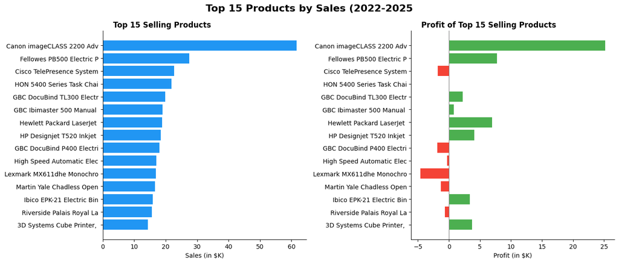

```
Top 10 Most Selling product Profit and Sales:
             product_name  Sales  Profit  Quantity  Discount_prct  Margin (%)
Canon imageCLASS 2200 Adv  61600   25200        20          12.00        41.0
Fellowes PB500 Electric P  27453    7753        31          24.00        28.0
Cisco TelePresence System  22638   -1811         6          50.00        -8.0
HON 5400 Series Task Chai  21871       0        39          20.00         0.0
GBC DocuBind TL300 Electr  19823    2234        37          30.00        11.0
GBC Ibimaster 500 Manual   19024     761        48          52.22         4.0
Hewlett Packard LaserJet   18840    6984        38          20.00        37.0
HP Designjet T520 Inkjet   18375    4095        12          16.67        22.0
GBC DocuBind P400 Electri  17965   -1878        27          45.00       -10.0
High Speed Automatic Elec  17030    -262        11           6.67        -2.0
```

```python
# Top 15 product by Analysis
top_products = df.groupby("product_name").agg(
    Sales = ("sales", lambda x: round(x.sum())),
    Profit = ("profit", lambda x: round(x.sum())),
    Quantity = ("quantity", "sum"),
    Discount_prct = ("discount", lambda x: round(x.mean() * 100, 2))).reset_index().sort_values("Sales", ascending=False).head(15)

top_products["product_name"] = top_products["product_name"].str[:25]
top_products["Margin (%)"] = (top_products["Profit"]/ top_products["Sales"] * 100).round()

colors_rg = ['#4CAF50' if x>=0 else '#F44336' for x in top_products['Profit']]

# Fig
fig, axes = plt.subplots(1,2, figsize=(14,6))
fig.suptitle("Top 15 Products by Sales (2022-2025", fontsize=16, fontweight="bold")

axes[0].barh(top_products["product_name"][::-1], top_products["Sales"][::-1] / 1e3, color=blue)
axes[0].set_title("Top 15 Selling Products", fontsize=12, fontweight="bold", loc="left", x=0.05)
axes[0].set_xlabel("Sales (in $K)")
axes[0].spines["top"].set_visible(False)
axes[0].spines["right"].set_visible(False)

axes[1].barh(top_products["product_name"][::-1], top_products["Profit"][::-1] / 1e3, color=colors_rg[::-1])
axes[1].set_title("Profit of Top 15 Selling Products", fontsize=12, fontweight="bold", loc="left", x=0.05)
axes[1].set_xlabel("Profit (in $K)")
axes[1].spines["top"].set_visible(False)
axes[1].spines["right"].set_visible(False)
axes[1].axvline(0, color='grey', linewidth=0.8 )

plt.tight_layout()
plt.show()

print("Top 10 Most Selling product Profit and Sales: ")
print(top_products.head(10).to_string(index=False))
```

### Insights: Top 15 Selling Proudcts

- Top-selling products are not always the most profitable. While some products generate high sales and strong profits, several high-demand products contribute little or negative profit due to high costs or heavy discounting. Products with strong sales and healthy profit margins should be promoted further, whereas consistently loss-making products should be reviewed for pricing, discount strategy, or potential discontinuation.

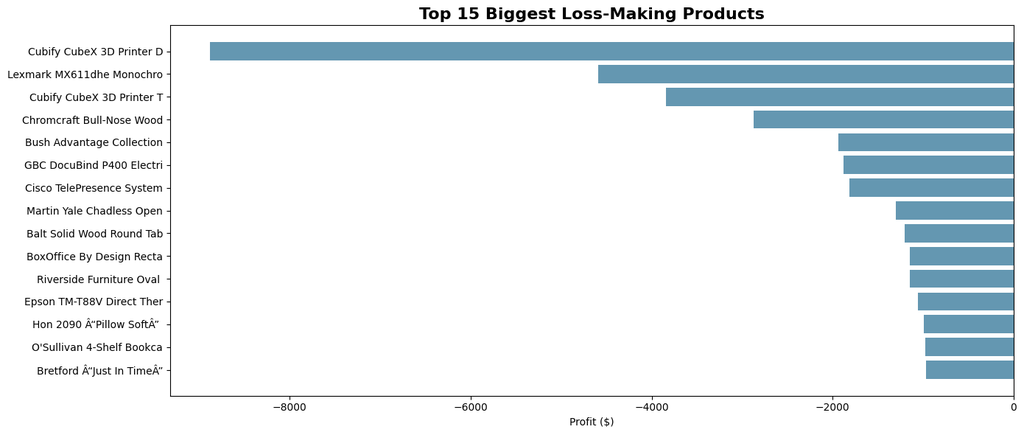

```
Top 10 Loss making product
             product_name  Sales  Profit  Quantity  Discount_prct  Margin (%)
Cubify CubeX 3D Printer D  11100   -8880         9          53.33       -80.0
Lexmark MX611dhe Monochro  16830   -4590        18          40.00       -27.0
Cubify CubeX 3D Printer T   8000   -3840         4          50.00       -48.0
Chromcraft Bull-Nose Wood   9918   -2876        27          28.00       -29.0
Bush Advantage Collection   9545   -1934        33          35.00       -20.0
GBC DocuBind P400 Electri  17965   -1878        27          45.00       -10.0
Cisco TelePresence System  22638   -1811         6          50.00        -8.0
Martin Yale Chadless Open  16656   -1299        22          10.00        -8.0
Balt Solid Wood Round Tab   6519   -1201        19          20.00       -18.0
BoxOffice By Design Recta   1706   -1148        15          48.33       -67.0
```

```python
# Top 15 wrost products by Profit
worst_product = df.groupby("product_name").agg(
    Sales = ("sales", lambda x: round(x.sum())),
    Profit = ("profit", lambda x: round(x.sum())),
    Quantity = ("quantity", "sum"),
    Discount_prct = ("discount", lambda x: round(x.mean() * 100, 2))).reset_index().sort_values("Profit").head(15)

worst_product["Margin (%)"] = (worst_product["Profit"]/ worst_product["Sales"] * 100).round()
worst_product["product_name"] = worst_product["product_name"].str[:25]

plt.figure(figsize=(14,6))
plt.title('Top 15 Biggest Loss-Making Products', fontsize=16, fontweight='bold')
plt.xlabel('Profit ($)')
plt.barh(worst_product["product_name"][::-1], worst_product["Profit"][::-1], color=colors[3])
plt.tight_layout()
plt.show()

print("Top 10 Loss making product")
print(worst_product.head(10).to_string(index=False))
```

### Insights: Top 15 worst performing products

The top loss-making products show a clear pattern of excessive discounting and weak profit margins. Most products with discounts above 40–50% generated significant losses despite moderate to high sales volumes.These products should be reviewed for pricing optimization, discount reduction, or possible discontinuation, while products with sustainable margins should receive greater promotional focus.

## 12) Correlation Heatmap

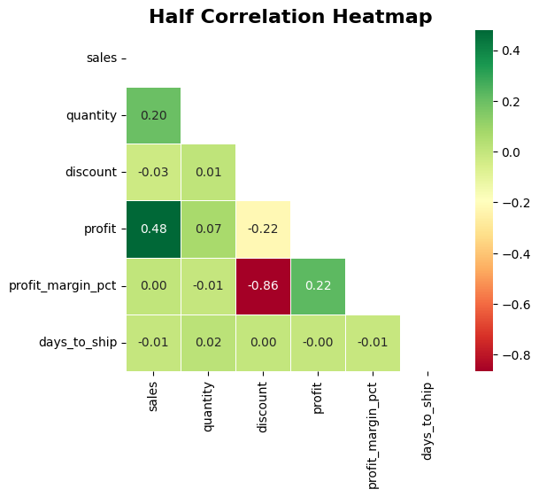

```python
columns = ["sales", "quantity", "discount", "profit", "profit_margin_pct", "days_to_ship"]
corr_matrix = df[columns].corr()

mask = np.triu(np.ones_like(corr_matrix, dtype=bool))

# Plot half heatmap
plt.figure(figsize=(6, 5))
sns.heatmap(corr_matrix, mask=mask,annot=True, cmap="RdYlGn", fmt=".2f", linewidth=0.5)
plt.title("Half Correlation Heatmap",fontsize=16, fontweight="bold")
plt.show()
plt.show()
```

### Insights: Correlation Matrix

- **Discount and Profit Margin have strong negative correlation (-0.86)**.
  - Discount shows a moderate negative correlation with profit (-0.22).
  - This relationship indicates that increasing discount levels heavily reduces profit margins and overall profitability.
- **Sales and Profit have a moderate positive correlation (0.48)**, meaning that an increase in sales generally contributes to higher profits.
  - This relationship is not that strong, suggesting profitability also depends on other factors such as discounts.
- **Quantity sold has a very weak positive correlation with sales (0.20) and an almost negligible relationship with profit (0.07).**
  - This suggests that simply increasing the number of units sold does not guarantee higher profitability.
- **Profit margin percentage has weak positive correlation with profit (0.22)**,
  - It indicates that products with higher margins do not always generate the highest total profit due to differences in sales volume.
- **Days to ship has almost no correlation with sales, profit, or profit margin**. -It shows that shipping time does not significantly influence financial performance in this dataset.

## 13) Key Findings and recommendataions

```python
print("-" * 50)
print("      ShopCart - Executive Summary (2022-2025)")
print("-" * 50)
print(f"    Total Revenue:          ${total_sales}")
print(f"    Total Profit:           ${total_profit}")
print(f"    Overall Profit Margin:  {overall_margin} %")
print(f"    Average Discount:       {avg_discount} %")
print(f"    Loss-making orders:     {loss_making_orders} ({loss_making_prct} %)")
print(f"    Total Orders:           {total_orders}")
print(f"    Total Customers:        {total_customers}")
print(f"    Average Shipping Days:  {avg_ship_days}")
```

```
--------------------------------------------------
      ShopCart - Executive Summary (2022-2025)
--------------------------------------------------
    Total Revenue:          $2297201
    Total Profit:           $286397
    Overall Profit Margin:  12.47 %
    Average Discount:       16.0 %
    Loss-making orders:     1871 (18.72 %)
    Total Orders:           5009
    Total Customers:        793
    Average Shipping Days:  3.96
```

### Recommendataions

#### 2) Control Excessive Discounting

- The analysis clearly shows that profitability declines as discount levels increase.
- The **No Discount** segment is the most profitable segment, generating approximately **320K USD in profit** with a **29.5% profit margin**.
- Heavy discounting may temporarily increase sales volume, but it significantly reduces profit margins and overall profitability.
- On average discounts above 20% result in loss-making orders.
- **Discounting should be managed strategically rather than used aggressively to drive sales volume. Most discounts should remain within the 0–10% range.**
- **Introduce approval policies for discounts exceeding 20%. Controlling excessive discounting could significantly improve profit margins without heavily impacting revenue.**

#### 3) Investigate the Furniture Category Thoroughly

- Furniture is one of the weakest-performing categories in terms of profitability. Despite generating strong sales, the category maintains a low average profit margin (~2.5%) and contains several loss-making sub-categories and products.
- Furniture also receives the highest average discount (~17.3%), which is significantly reducing profitability.
- Sub-categories such as Tables and Bookcases are major contributors to losses and receive some of the highest discount levels within the category.
- **The Furniture category requires deeper investigation to identify the root causes of continuous losses and understand why heavy discounting is necessary across several furniture sub-categories.**

#### 4) Focus More on High-Margin Customer Segments

- The Consumer segment generates the highest sales volume (~50%) but generates comparatively weaker profit margins (~11.5%).
- In contrast, the Home Office segment generates stronger profit margins and higher average order values despite lower overall sales.
- This suggests that Home Office customers are more profitable on a per-order basis.
- **Increase marketing and retention efforts for Home Office and Corporate customers through targeted campaigns, personalized offers, and upselling strategies.**

#### 5) Review the Central Region Performance

- Regional analysis shows that the East and West regions perform strongly in both sales and profitability.
- However, the Central region is underperforming and operates with significantly lower profit margins.
- The Central region also has relatively high discount levels (~24%), which are negatively impacting profitability.
- **A detailed investigation of the Central region is required to identify pricing issues, operational inefficiencies, and excessive discounting.**
- **Re-examine the discount strategy in the Central region — although sales are strong, profit margins remain significantly low.**

#### 6) Prepare Earlier for Q4 Demand

- Our analysis shows a clear and recurring increase in sales during Q4 across all four years, making it one of the most important revenue-generating periods for the business.
- **The company should strengthen Q4 planning by building inventory earlier, optimizing logistics operations, and launching seasonal marketing campaigns ahead of peak demand.**

#### 7) Monitor High-Sales but Low-Profit Products

- Several products generate strong revenue but consistently produce weak or negative profits, indicating that high sales do not always translate into strong business profitability.
- Not all top-selling products are highly profitable.
- **The company should regularly monitor product-level profitability alongside sales performance. Loss-making products should be reviewed for pricing strategy, discount dependency, shipping costs, and operational inefficiencies.**

#### 8) Focus on High-Profit Categories

- Technology and several Office Supplies sub-categories generated the highest profits while maintaining stronger margins compared to Furniture products.
- **ShopCart should prioritize high-margin categories and sub-categories when allocating marketing budgets, inventory investment, and promotional efforts to maximize overall profitability.**